# HW3_Analysis_Of_Complex_Network

**Analysis Of Complex Network Course Homework3** **Yashar Movahedi** **Student** **Id:0232113102** **Group:6**

(a) Generate graphs based on Watts-Strogatz Model, and each of them should have the same number of nodes as Facebook-Ego. Please generate 9 graphs with three different values of ¯k and p. Please plot the graph structures, degree distributions, and clustering coefficients as well.

```python
import matplotlib.pyplot as plt
import networkx as nx
import numpy as np
import collections
from pprint import pprint
import random
```

```python
# first i have to read my file and count the number of nodes in my facebook dataset

facebook_G = nx.read_edgelist(r'C:\Users\Vampire\Desktop\complex\facebook\1684(1).edges', nodetype=int)

facebook_num_nodes = facebook_G.number_of_nodes()
print(f'Number of nodes in Facebook Network: {facebook_num_nodes}')
```

```
Number of nodes in Facebook Network: 157
```

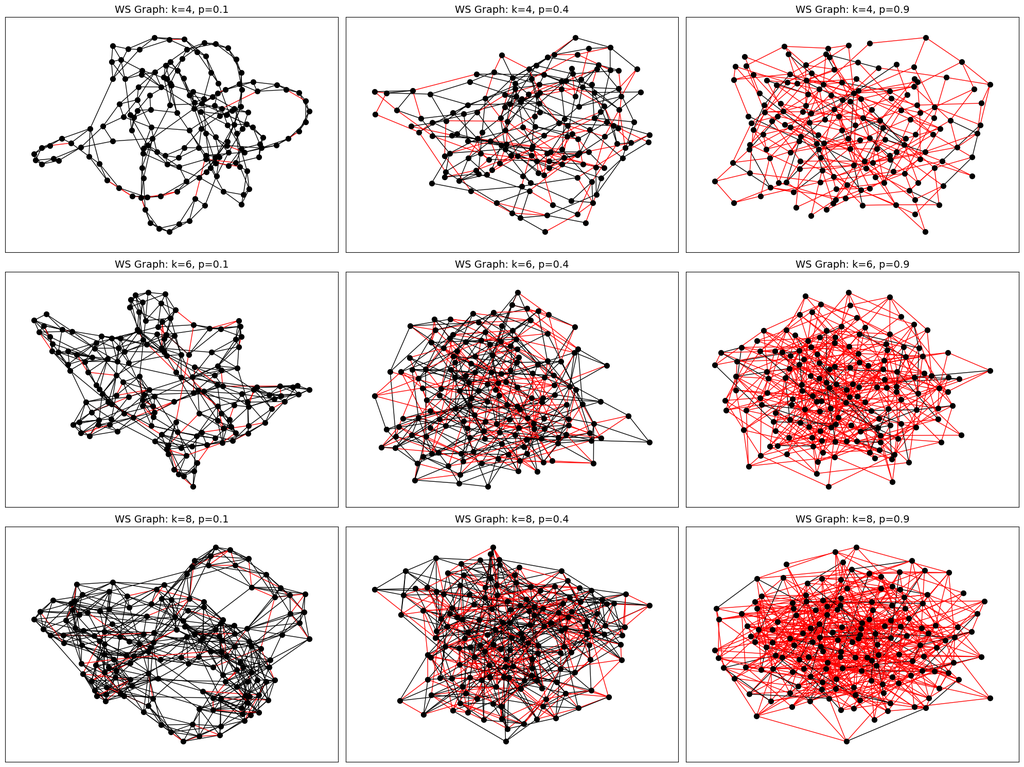

```python
k_values = [4, 6, 8]  # Average degrees
p_values = [0.1, 0.4, 0.9]  # Rewiring probabilities

fig_graphs, axs_graphs = plt.subplots(len(k_values), len(p_values), figsize=(20, 15))

clustering_coefficients = []
degree_distributions = []

# repeating over each combination of k and p values to generate graphs
for i, k in enumerate(k_values):
    for j, p in enumerate(p_values):
        # Generate Watts-Strogatz graph
        G = nx.watts_strogatz_graph(facebook_num_nodes, k, p)

        # Calculate positions for visualization
        pos = nx.spring_layout(G)

        # edge colors based on rewiring probability
        edge_colors = ['red' if random.random() < p else 'black' for _ in G.edges()]


        axs_graphs[i, j].set_title(f'WS Graph: k={k}, p={p}', fontsize=14)
        nx.draw_networkx(G, pos, node_size=50, ax=axs_graphs[i, j], with_labels=False,
                         edge_color=edge_colors, node_color='black')

        axs_graphs[i, j].set_xticks([])
        axs_graphs[i, j].set_yticks([])

        # Calculate clustering coefficient and store it
        clustering_coeff = nx.average_clustering(G)
        clustering_coefficients.append((k, p, clustering_coeff))

        # Calculate degree distribution and store it
        degrees = [G.degree(n) for n in G.nodes()]
        degree_distribution, bins = np.histogram(degrees, bins=np.arange(0, max(degrees) + 2))
        degree_distributions.append((k, p, bins[:-1], degree_distribution))

plt.tight_layout()
plt.show()
```

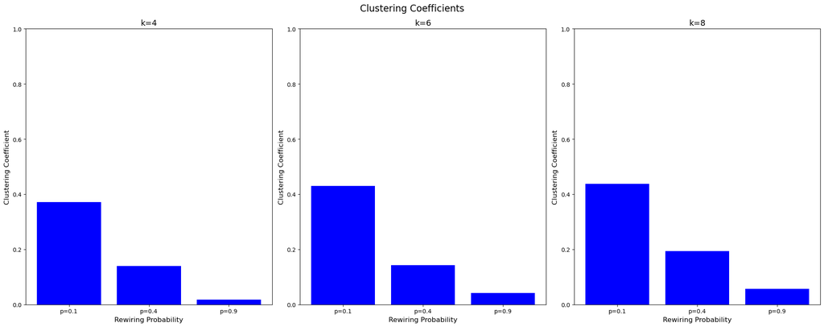

```python
import matplotlib.pyplot as plt

# Define the k_values and p_values
k_values = [4, 6, 8]  # Average degrees
p_values = [0.1, 0.4, 0.9]  # Rewiring probabilities

# Plotting Clustering Coefficients
fig_clustering, axs_clustering = plt.subplots(1, len(k_values), figsize=(20, 8))  # 1 row, len(k_values) columns
fig_clustering.suptitle('Clustering Coefficients', fontsize=16)

for i, k in enumerate(k_values):
    # Get clustering coefficients for the current k across all p values
    coeffs = [c[2] for c in clustering_coefficients if c[0] == k]

    # Bar plot for current k
    axs_clustering[i].bar([f'p={p}' for p in p_values], coeffs, color='blue')
    axs_clustering[i].set_ylim(0, 1)
    axs_clustering[i].set_title(f'k={k}', fontsize=14)
    axs_clustering[i].set_xlabel('Rewiring Probability', fontsize=12)
    axs_clustering[i].set_ylabel('Clustering Coefficient', fontsize=12)

plt.tight_layout()
plt.show()
```

```python
clustering_coefficients = []

# Calculate clustering coefficients for the previously generated graphs
for k in k_values:
    for p in p_values:
        # Generate Watts-Strogatz graph with 157 nodes
        G = nx.watts_strogatz_graph(157, k, p)

        # Calculate the average clustering coefficient
        clustering_coeff = nx.average_clustering(G)
        clustering_coefficients.append((k, p, clustering_coeff))

# Display the results
for k, p, coeff in clustering_coefficients:
    print(f'Clustering coefficient for k={k}, p={p}: {coeff}')
```

```
Clustering coefficient for k=4, p=0.1: 0.35690021231422503
Clustering coefficient for k=4, p=0.4: 0.13527449196239003
Clustering coefficient for k=4, p=0.9: 0.02368820139520776
Clustering coefficient for k=6, p=0.1: 0.4702254574866039
Clustering coefficient for k=6, p=0.4: 0.154423213021939
Clustering coefficient for k=6, p=0.9: 0.04538805143900682
Clustering coefficient for k=8, p=0.1: 0.4314721372046213
Clustering coefficient for k=8, p=0.4: 0.1624816089784241
Clustering coefficient for k=8, p=0.9: 0.05418848667256304
```

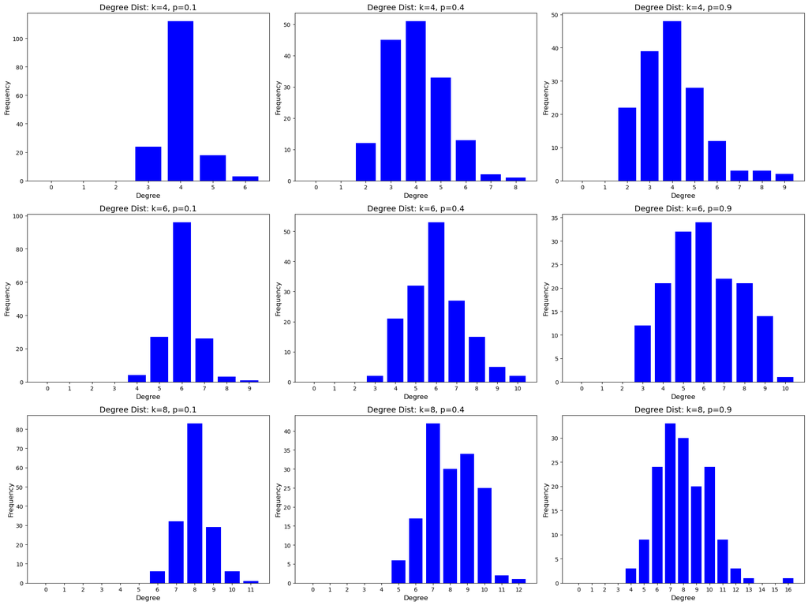

```python
# Plotting Degree Distributions
fig_degree, axs_degree = plt.subplots(len(k_values), len(p_values), figsize=(20, 15))

for i, k in enumerate(k_values):
    for j, p in enumerate(p_values):
        # Get degree distribution for current (k, p)
        bins, distribution = [(d[2], d[3]) for d in degree_distributions if d[0] == k and d[1] == p][0]

        # Plot the degree distribution
        axs_degree[i, j].bar(bins, distribution, width=0.8, color='blue')
        axs_degree[i, j].set_title(f'Degree Dist: k={k}, p={p}', fontsize=14)
        axs_degree[i, j].set_xlabel('Degree', fontsize=12)
        axs_degree[i, j].set_ylabel('Frequency', fontsize=12)

        # Set x-ticks to show all degrees
        axs_degree[i, j].set_xticks(bins)  # Set ticks to be all bin centers
        axs_degree[i, j].set_xticklabels(bins)  # Set labels to be the same as tick positions

plt.tight_layout()
plt.show()
```

(b) Generate scale-free graphs, and each of them should have the same number of nodes as Facebook- Ego. Please generate 3 graphs with three different values of γ. Please plot the graph structures, degree distributions, and clustering coefficients as well.

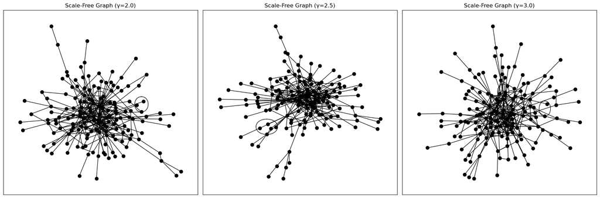

```python
gamma_values = [2.0, 2.5, 3.0]

graphs = []
average_clustering_coeffs = []
degree_distributions = []

for gamma in gamma_values:
    # Generate a scale-free graph with 157 nodes
    G = nx.scale_free_graph(157, delta_in=gamma, delta_out=gamma, seed=42)
    G = nx.Graph(G)  # Convert to a simple graph to avoid multigraph issues
    G = G.to_undirected()
    graphs.append(G)

    # Calculate the average clustering coefficient
    avg_cc = nx.average_clustering(G)
    average_clustering_coeffs.append(avg_cc)

    # Calculate the degree sequence
    degree_sequence = [d for n, d in G.degree()]
    degree_distributions.append(degree_sequence)

# Plot the scale-free graphs
fig, axs = plt.subplots(1, len(gamma_values), figsize=(18, 6))

for i, G in enumerate(graphs):
    pos = nx.spring_layout(G, seed=42)
    axs[i].set_title(f'Scale-Free Graph (γ={gamma_values[i]})')
    nx.draw_networkx(G, pos, node_size=50, ax=axs[i], with_labels=False, node_color='black')

plt.tight_layout()
plt.show()
```

[figure not shown]

```python
# Calculate degree distributions for each generated scale-free graph
degree_distributions = []

for gamma in gamma_values:
    # Generate the scale-free graph with the same parameters as before
    alpha = gamma / (gamma + 1)
    beta = (1 - alpha) / 2
    gamma_param = (1 - alpha) / 2
    G = nx.scale_free_graph(facebook_num_nodes, alpha=alpha, beta=beta, gamma=gamma_param)

    # Convert to an undirected graph
    G = G.to_undirected()

    # Get the degree sequence for the graph
    degree_sequence = [d for n, d in G.degree()]
    degree_distributions.append(degree_sequence)

# Plot degree distributions
fig, axs = plt.subplots(1, len(gamma_values), figsize=(18, 6))

for i, degree_sequence in enumerate(degree_distributions):
    # Create a histogram of the degree distribution
    axs[i].hist(degree_sequence, bins=30, alpha=0.7, color='blue', edgecolor='black')
    axs[i].set_title(f'Degree Distribution (γ={gamma_values[i]})')
    axs[i].set_xlabel('Degree')
    axs[i].set_ylabel('Frequency')

plt.tight_layout()
plt.show()
```

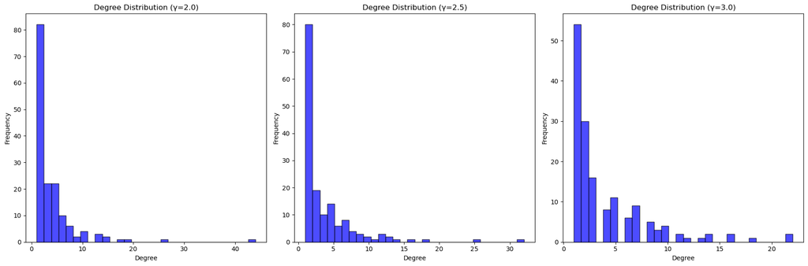

```python
# Define gamma_values if not already defined
gamma_values = [2.0, 2.5, 3.0]

# Make sure degree_distributions is already calculated from previous steps
# Plot degree distributions for the scale-free graphs with 157 nodes
fig, axs = plt.subplots(1, len(gamma_values), figsize=(18, 6))

for i, degree_sequence in enumerate(degree_distributions):
    # Create a histogram of the degree distribution
    axs[i].hist(degree_sequence, bins=30, alpha=0.7, color='blue', edgecolor='black')
    axs[i].set_title(f'Degree Distribution (γ={gamma_values[i]})')
    axs[i].set_xlabel('Degree')
    axs[i].set_ylabel('Frequency')

plt.tight_layout()
plt.show()
```

```python
average_clustering_coeffs = []

# Calculate average clustering coefficients for the generated graphs
for G in graphs:
    # Calculate the average clustering coefficient for the current graph
    avg_cc = nx.average_clustering(G)
    average_clustering_coeffs.append(avg_cc)

# Display the results
for i, gamma in enumerate(gamma_values):
    print(f'Average clustering coefficient for γ={gamma}: {average_clustering_coeffs[i]}')
```

```
Average clustering coefficient for γ=2.0: 0.06114758901442503
Average clustering coefficient for γ=2.5: 0.06094798077266001
Average clustering coefficient for γ=3.0: 0.04756039284543948
```

[figure not shown]

```python
# Plot the average clustering coefficients
bar_width = 0.2
x_indices = np.arange(len(gamma_values))

fig, ax = plt.subplots(figsize=(8, 6))
ax.bar(x_indices, average_clustering_coeffs, width=bar_width, color='orange', edgecolor='black')
ax.set_xlabel('γ Value')
ax.set_ylabel('Average Clustering Coefficient')
ax.set_xticks(x_indices)
ax.set_xticklabels(gamma_values)

plt.tight_layout()
plt.show()
```

(c) Generate graphs based on Barab´asi-Albert Model, and each of them should have the same number of nodes as Facebook-Ego. Please generate 9 graphs with three different values of m0 and m. Please plot the graph structures, degree distributions, and clustering coefficients as well

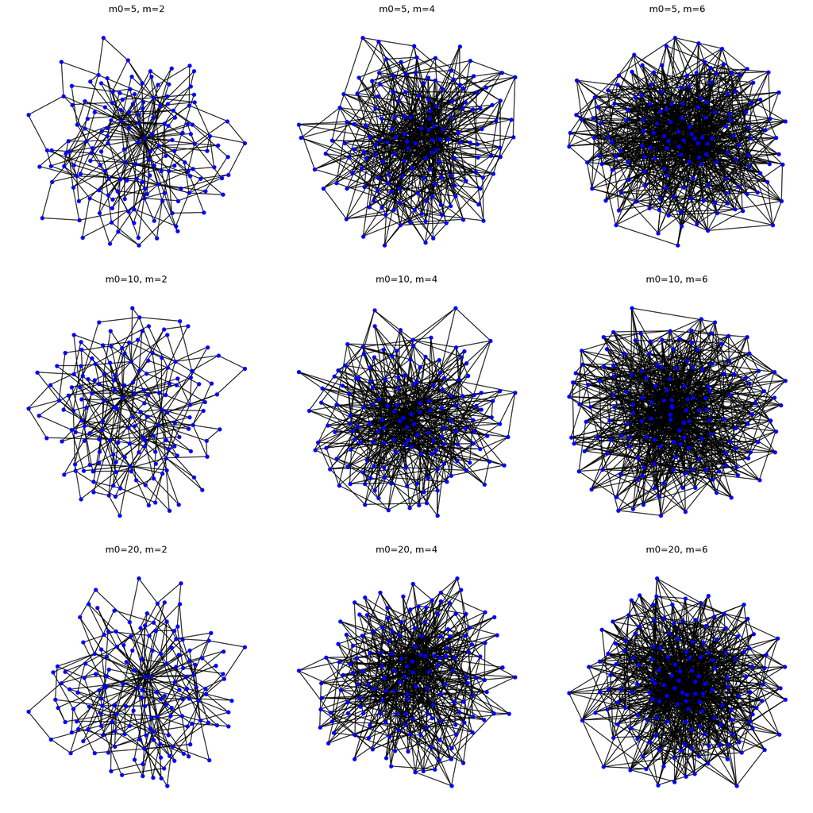

```python
m0_values = [5, 10, 20]
m_values = [2, 4, 6]

graphs = []
labels = []

# Generate 9 Barabási-Albert graphs based on combinations of m0 and m
for m0 in m0_values:
    for m in m_values:
        ba_graph = nx.barabasi_albert_graph(157, m)  # Using 157 nodes from my facebook dataset as i calculated in first HW
        graphs.append(ba_graph)
        labels.append(f'm0={m0}, m={m}')

# Plot the generated graphs
fig, axs = plt.subplots(3, 3, figsize=(15, 15))
for i, graph in enumerate(graphs):
    pos = nx.spring_layout(graph, seed=42)  # Set seed for consistent layout
    row, col = divmod(i, 3)  # Calculate row and column positions for the subplot
    nx.draw(graph, pos, ax=axs[row, col], node_size=20, node_color='blue', with_labels=False)
    axs[row, col].set_title(labels[i])  # Use the label for m0 and m

plt.tight_layout()
plt.show()
```

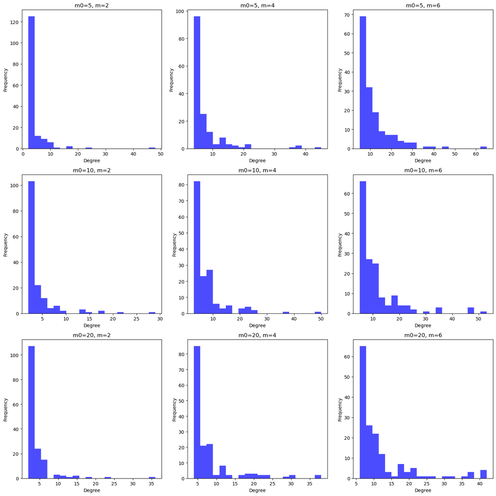

```python
# Plot the degree distributions for the 9 generated Barabási-Albert graphs
fig, axs = plt.subplots(3, 3, figsize=(15, 15))

for i, graph in enumerate(graphs):
    degrees = [deg for _, deg in graph.degree()]  # Get the degree of each node
    row, col = divmod(i, 3)  # Determine the subplot row and column
    axs[row, col].hist(degrees, bins=20, color='blue', alpha=0.7)  # Plot histogram
    axs[row, col].set_title(f'm0={m0_values[row]}, m={m_values[col]}')  # title
    axs[row, col].set_xlabel('Degree')  # X-axis label
    axs[row, col].set_ylabel('Frequency')  # Y-axis label

plt.tight_layout()
plt.show()
```